# **One-Way Analysis of Variance**

**STA4173: Biostatistics**  
Spring 2025

## Introduction: Analysis of Variance

- We have previously discussed testing the difference between two groups.
  - What about when there are three or more groups?
- We will use a method called **an**alysis **o**f **va**riance (ANOVA).
  - This method partitions the variance of the outcome into variance due to the groups and variance due to “other” factors.
- Fun fact: the two-sample *t*-test is a special case of ANOVA.
  - If you perform ANOVA when comparing two means, you will obtain the same results as the two-sample *t*-test.

## Hypotheses

- Hypotheses all take the same form:
  - $H_0: \ \mu_1 = \mu_2 = ... = \mu_k$
  - $H_1:$ at least one is different
- Note 1: you must fill in the “k” when writing hypotheses!
  - e.g., if there are four means, your hypotheses are
    - $H_0: \ \mu_1 = \mu_2 = \mu_3 = \mu_4$
    - $H_1:$ at least one is different
- Note 2: ANOVA does not tell us which means are different, just if a general difference exists!

## ANOVA Table

- The computations for ANOVA are more involved than what we’ve seen before.
- An ANOVA table will be constructed in order to perform the hypothesis test.

| **Source** | **Sum of Squares** | **df** | **Mean Squares** | *F* |
| --- | --- | --- | --- | --- |
| Treatment | SS<sub>Trt</sub> | df<sub>Trt</sub> | MS<sub>Trt</sub> | *F*<sub>0</sub> |
| Error | SS<sub>E</sub> | df<sub>E</sub> | MS<sub>E</sub> |  |
| Total | SS<sub>Tot</sub> | df<sub>Tot</sub> |  |  |

- Once this is put together, we can perform the hypothesis test.
  - Our test statistic is the *F*<sub>0</sub>.

## The *F* Distribution

- The *F* distribution is derived as the ratio of two variances.
  - The variances each have degrees of freedom: df<sub>numerator</sub> and df<sub>denominator</sub>
- The *F* distribution’s shape depends on the df,

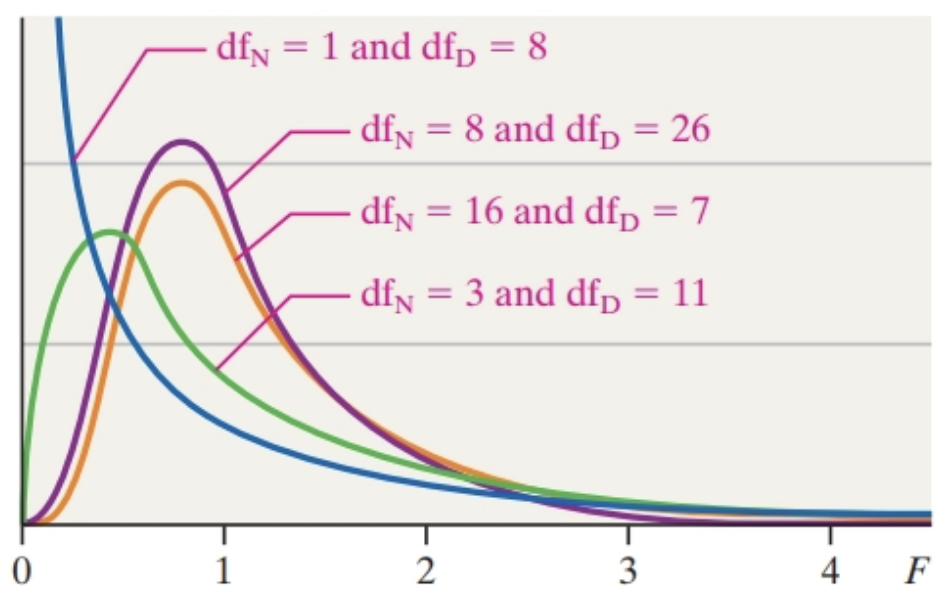

## ANOVA Computations

- Again, here’s where we are headed with our computations:

| **Source** | **Sum of Squares** | **df** | **Mean Squares** | *F* |
| --- | --- | --- | --- | --- |
| Treatment | SS<sub>Trt</sub> | df<sub>Trt</sub> | MS<sub>Trt</sub> | *F*<sub>0</sub> |
| Error | SS<sub>E</sub> | df<sub>E</sub> | MS<sub>E</sub> |  |
| Total | SS<sub>Tot</sub> | df<sub>Tot</sub> |  |  |

- We are partitioning the variance of our outcome into:
  - Variance due to the grouping (treatment)
  - Variance due to “other” factors (error)
    - Think of this like a “catch all” for other sources of error – things we did not adjust for in our model.

## ANOVA Computations

- Before we begin our computations, it would be helpful if we know

$$\bar{x}, \ \ n_i, \ \ \bar{x}_i, \ \ s_i^2$$

- where,
  - $\bar{x}$ is the overall mean,
  - $n_i$ is the sample size for group $i$,
  - $\bar{x}_i$ is the mean for group $i$, and
  - $s_i^2$ is the variance for group $i$

## ANOVA Computations

- We begin our computations with the sums of squares:

$$\begin{align*}
\text{SS}_{\text{Trt}} &= \sum_{i=1}^k n_i(\bar{x}_i-\bar{x})^2 \\
\text{SS}_{\text{E}} &= \sum_{i=1}^k (n_i-1)s_i^2 \\
\text{SS}_{\text{Tot}} &= \text{SS}_{\text{Trt}} + \text{SS}_{\text{E}}
\end{align*}$$

- and each sum of squares has degrees of freedom:
  - $\text{df}_{\text{Trt}} = k-1$ (number of groups – 1)
  - $\text{df}_{\text{E}} = n-k$ (overall sample size – number of groups)
  - $\text{df}_{\text{Tot}} = n-1$ (overall sample size – 1) = $\text{df}_{\text{Trt}} + \text{df}_{\text{E}}$

## ANOVA Computations

- Once we have the sum of squares and corresponding degrees of freedom, we have the mean squares.
- Generally, mean squares are the sum of square divided by the df,
  $$\text{MS}_X = \frac{\text{SS}_X}{\text{df}_X}$$
- In the case of one-way ANOVA,
  $$\begin{align*}
  \text{MS}_{\text{Trt}} &= \frac{\text{SS}_{\text{Trt}}}{\text{df}_{\text{Trt}}} \\
  \text{MS}_{\text{E}} &= \frac{\text{SS}_{\text{E}}}{\text{df}_{\text{E}}}
  \end{align*}$$
  - Note that there is **no** $\text{MS}_{\text{Tot}}$!

## ANOVA Computations

- Finally, we have the test statistic.
- Generally, we construct an $F$ for ANOVA by dividing the MS of interest by MS$_{\text{E}}$,
  $$F_X = \frac{\text{MS}_X}{\text{MS}_{\text{E}}}$$
- In one-way ANOVA, we are only constructing the $F$ for treatment,
  $$F_0 = \frac{\text{MS}_{\text{Trt}}}{\text{MS}_{\text{E}}}$$

## ANOVA Computations

- We are finally done constructing our ANOVA table! As a reminder,

| **Source** | **Sum of Squares** | **df** | **Mean Squares** | *F* |
| --- | --- | --- | --- | --- |
| Treatment | SS<sub>Trt</sub> | df<sub>Trt</sub> | MS<sub>Trt</sub> | *F*<sub>0</sub> |
| Error | SS<sub>E</sub> | df<sub>E</sub> | MS<sub>E</sub> |  |
| Total | SS<sub>Tot</sub> | df<sub>Tot</sub> |  |  |

## ANOVA: R Syntax

- We can use the `aov()` and `summary()` functions.

```r
m <- aov(continuous_variable ~ grouping_variable,
         data = dataset_name)
summary(m)
```

- However, note that ANOVA is regression (and regression is ANOVA).
  - We can also use `lm()` to define the model and `anova()` to construct the ANOVA table.

```r
m <- lm(continuous_variable ~ grouping_variable,
         data = dataset_name)
anova(m)
```

## Example - Dental

- Prosthodontists specialize in the restoration of oral function, including the use of dental implants, veneers, dentures, and crowns. A researcher wanted to compare the shear bond strength of different repair kits for repairs of chipped porcelain veneer.
- He randomly divided 20 porcelain specimens into four treatment groups: group 1 used the Cojet system, group 2 used the Silistor system, group 3 used the Cimara system, and group 4 used the Ceramic Repair system.
- At the conclusion of the study, shear bond strength (in megapascals, MPa) was measured according to ISO 10477. The data are as follows,

```r
strength <- c(15.4, 12.9, 17.2, 16.6, 19.3,
              17.2, 14.3, 17.6, 21.6, 17.5,
               5.5,  7.7, 12.2, 11.4, 16.4,
              11.0, 12.4, 13.5,  8.9,  8.1)
system <- c(rep("Cojet",5), rep("Silistor",5), rep("Cimara",5), rep("Ceramic",5))
data <- tibble(system, strength)
```

## Example - Dental

| system | strength |
| --- | --- |
| Cojet | 15.4 |
| Cojet | 12.9 |
| Cojet | 17.2 |

- What is the continuous variable?
- What is the grouping variable?

## Example - Dental

- Our first step will be to construct an ANOVA table for the data.

```r
m1 <- aov(strength ~ system, data = data)
summary(m1)
```

```
            Df Sum Sq Mean Sq F value  Pr(>F)
system       3  200.0   66.66   7.545 0.00229 **
Residuals   16  141.4    8.84
---
Signif. codes:  0 '***' 0.001 '**' 0.01 '*' 0.05 '.' 0.1 ' ' 1
```

```r
m2 <- lm(strength ~ system, data = data)
anova(m2)
```

|  | Df | Sum Sq | Mean Sq | F value | Pr(>F) |
| --- | --- | --- | --- | --- | --- |
| system | 3 | 199.9855 | 66.66183 | 7.545199 | 0.002294591 |
| Residuals | 16 | 141.3600 | 8.83500 | NA | NA |

## Hypothesis Testing

- **Hypotheses**
  - $H_0: \ \mu_1 = \mu_2 = ... = \mu_k$
  - $H_1:$ at least one mean is different
- **Test Statistic**
  - $F_0$ (pulled from the ANOVA table)
- *p*-Value
  - $p = P[F_0 \ge F_{\text{df}_{\text{Trt}}, \text{df}_{\text{E}}}]$
- **Rejection Region**
  - Reject $H_0$ if $p<\alpha$.

## Example - Dental

- Using the dental data:

```r
summary(m1)
```

```
            Df Sum Sq Mean Sq F value  Pr(>F)
system       3  200.0   66.66   7.545 0.00229 **
Residuals   16  141.4    8.84
---
Signif. codes:  0 '***' 0.001 '**' 0.01 '*' 0.05 '.' 0.1 ' ' 1
```

- Determine if there is a difference in average strength between the groups. Test at the $\alpha=0.01$ level.

## Example - Dental

- **Hypotheses**
  - $H_0: \ \mu_1 = \mu_2 = \mu_3 = \mu_4$
  - $H_1:$ at least one mean is different
- **Test Statistic and *p*-Value**
  - $F_0 = 7.545$
  - $p = 0.002$
- **Rejection Region**
  - Reject $H_0$ if $p<\alpha$; $\alpha = 0.01$.
- **Conclusion/Interpretation**
  - Reject $H_0$. There is sufficient evidence to suggest that there is a difference in average strength between the four groups.

## Introduction: Posthoc Testing

- Today we have introduced ANOVA. Recall the hypotheses,
  - $H_0: \mu_1 = \mu_2 = ... = \mu_k$
  - $H_1:$ at least one $\mu_i$ is different
- The $F$ test does not tell us *which* mean is different… only that a difference exists.
- In theory, we could perform repeated $t$ tests to determine pairwise differences.
  - Recall that ANOVA is an extension of the $t$ test… or that the $t$ test is a special case of ANOVA.
  - However, this will increase the Type I error rate ($\alpha$).

## Introduction: Posthoc Testing

- Recall that the Type I error rate, $\alpha$, is the probability of *incorrectly* rejecting $H_0$.
  - i.e., we are saying there is a difference between the means when there is actually *not* a difference.
- Suppose we are comparing 5 groups.
  - This is 10 pairwise comparisons!!
    - 1-2, 1-3, 1-4, 1-5, 2-3, 2-4, 2-5, 3-4, 3-5, 4-5
  - If we perform repeated $t$ tests under $\alpha=0.05$, we are inflating the Type I error to 0.40! 😵

## Introduction: Posthoc Testing

- When performing posthoc comparisons, we can choose one of two paths:
  - Control the Type I (familywise) error rate.
  - Do not control the Type I error rate.
- Note that controlling the Type I error rate is more conservative than when we do not control it.
  - “Conservative” = more difficult to reject.
- Generally, statisticians:
  - *do not* control the Type I error rate if examining the results of pilot/preliminary studies that are exploring for general relationships.
  - *do* control the Type I error rate if examining the results of confirmatory studies and are attempting to confirm relationships observed in pilot/preliminary studies.

## Introduction: Posthoc Testing

- The posthoc tests we will learn:
  - Tukey’s test
    - Performs all pairwise tests and controls the Type I error rate
  - Fisher’s least significant difference
    - Performs all pairwise tests but does not control the Type I error rate
  - Dunnett’s test
    - Compares each group to a control group and controls the Type I error rate
- **Caution**: we should *only* perform posthoc tests if we have determined that a general difference exists!
  - i.e., we rejected when looking at the $F$ test in ANOVA

## Example

- Recall the dental example from earlier,

```r
m1 <- aov(strength ~ system, data = data)
summary(m1)
```

```
            Df Sum Sq Mean Sq F value  Pr(>F)
system       3  200.0   66.66   7.545 0.00229 **
Residuals   16  141.4    8.84
---
Signif. codes:  0 '***' 0.001 '**' 0.01 '*' 0.05 '.' 0.1 ' ' 1
```

- Are we justified in posthoc testing? (Recall: $\alpha=0.01$).

## Tukey’s Test

- Tukey’s test allows us to do all pairwise comparisons while controlling $\alpha$.
- The underlying idea of the comparison:
  - We declare $\mu_i \ne \mu_j$ if $|\bar{y}_i - \bar{y}_j| \ge W$, where
    $$W = \frac{q_{\alpha}(k, \text{df}_{\text{E}})}{\sqrt{2}} \sqrt{\text{MSE} \left( \frac{1}{n_i} + \frac{1}{n_j} \right)}$$
    - $q_{\alpha}(k, \text{df}_{\text{E}})$ is the critical value from the Studentized range distribution.
- We will use the [`TukeyHSD()`](https://www.rdocumentation.org/packages/stats/versions/3.6.2/topics/TukeyHSD) function.
  - Note that this requires us to have created our model using the `aov()` function.

```r
m <- aov(continuous_variable ~ grouping_variable, data = dataset_name)
TukeyHSD(m)$grouping_variable
```

## Tukey’s Test

- Let’s apply Tukey’s to the dental data.

```r
m <- aov(strength ~ system, data = data)
TukeyHSD(m, conf.level = 0.99)$system
```

```
                  diff         lwr       upr       p adj
Cimara-Ceramic   -0.14 -7.04151507  6.761515 0.999845202
Cojet-Ceramic     5.50 -1.40151507 12.401515 0.044147158
Silistor-Ceramic  6.86 -0.04151507 13.761515 0.010458208
Cojet-Cimara      5.64 -1.26151507 12.541515 0.038206781
Silistor-Cimara   7.00  0.09848493 13.901515 0.008990873
Silistor-Cojet    1.36 -5.54151507  8.261515 0.886304336
```

- Which are significantly different at the $\alpha=0.01$ level?

## Fisher’s Test

```r
library(agricolae)
results <- summary(m)
(LSD.test(dataset_name$continuous_variable, # continuous outcome
          dataset_name$grouping_variable, # grouping variable
          results[[1]]$Df[2], # df_E
          results[[1]]$`Mean Sq`[2], # MSE
          alpha = alpha_level) # can omit if alpha = 0.05
  )[5] # limit to only the pairwise comparison results
```

## Fisher’s Test

- Let’s apply Fisher’s to the dental data.

```r
library(agricolae)
results <- summary(m)
LSD.test(data$strength,
         data$system,
         results[[1]]$Df[2],
         results[[1]]$`Mean Sq`[2],
         alpha = 0.01)[5]
```

```
$groups
         data$strength groups
Silistor         17.64      a
Cojet            16.28      a
Ceramic          10.78      b
Cimara           10.64      b
```

- Which are significantly different at the $\alpha=0.01$ level?

## Dunnett’s Test

- Dunnett’s test allows us to do all pairwise comparisons against only the control, while controlling $\alpha$.
  - This has fewer comparisons than Tukey’s because we are not comparing non-control groups to one another.
  - i.e., we are sharing the $\alpha$ between fewer comparisons now, which is preferred if we are not interested in the comparisons between non-control groups.
- The underlying idea of the comparison:
  - We declare $\mu_i \ne \mu_j$ if $|\bar{y}_i - \bar{y}_j| \ge D$, where
    $$D = d_{\alpha}(k-1, \text{df}_{\text{E}}) \sqrt{\text{MSE} \left( \frac{1}{n_i} + \frac{1}{n_c} \right)},$$
    - $d_{\alpha}(k-1, \text{df}_{\text{E}})$ is the critical value from Dunnett’s table.

## Dunnett’s Test

- We will use the [`DunnettTest()`](https://www.rdocumentation.org/packages/DescTools/versions/0.99.32/topics/DunnettTest) function from the DescTools package to perform Dunnett’s test.

```r
library(DescTools)
DunnettTest(x=dataset_name$continuous_variable,
            g=dataset_name$grouping_variable,
            control = "name of control group")
```

- The *p*-values are adjusted, so you can directly compare them to the specified $\alpha$.

## Dunnett’s Test

- Let’s apply Dunnett’s to the dental data.
  - We will treat “Ceramic” as the control group.

```r
library(DescTools)
DunnettTest(x=data$strength,
            g=data$system,
            control = "Ceramic")
```

```
  Dunnett's test for comparing several treatments with a control :
    95% family-wise confidence level

$Ceramic
                  diff     lwr.ci    upr.ci   pval
Cimara-Ceramic   -0.14 -5.0138317  4.733832 0.9997
Cojet-Ceramic     5.50  0.6261683 10.373832 0.0259 *
Silistor-Ceramic  6.86  1.9861683 11.733832 0.0059 **

---
Signif. codes:  0 '***' 0.001 '**' 0.01 '*' 0.05 '.' 0.1 ' ' 1
```

- Which are significantly different at the $\alpha=0.01$ level?